# Results of ARDL estiations with covariates

Lio, Orestis

03/09/2020

## Intro

This report provides an overview of the results obtained from the ARDL estimations that account for climatic variables as developed on 26th of August (aka ‘last Wednesday’).

Brief summary of the model: up to 7 lags (1 week) for both dependent and independent variable, dependent variable is movement, independent variables are stringency index, precipitation and temperature.

Note 1: Only units with at least 50 observations were retained, as otherwise there would be computational errors (I suppose degrees of freedom exhausted with 7*4 variables as well as constant, etc.)

Note 2: We take first differences of all series, which is because they are very obviously non-stationary.

Note 3: Computational errors arose from constant precipitation series in dry regions. We added a random small error term to the series as a quick fix. A cleaner solution would be to confirm if there is variation for each country before estimating, and to remove the variable if there isn’t any.

## Data

To simplify / accellerate things, I saved the results of the estimations in code/ARDL_cov_03092020.Rds.

The data comes as a list of 5 items:

```r
ARDL_cov <- readRDS("ARDL_cov_03092020.Rds")
str(ARDL_cov,1)
```

```
## List of 5
##  $ bgtest :List of 411
##  $ bic    :List of 411
##  $ longrun:List of 411
##  $ model  :List of 411
##  $ summary:'data.frame': 411 obs. of  8 variables:
```

The first 3 elements are lists of matrices: e.g., bgtest has a 7*7 matrix for each country, reporting the p-value of the breush-godfrey test for all combinations of lag-lengths p and q.

Item 4 stores the entire model for each city, that includes all coefficients and their SEs.

Item 5 is a dataframe with one entry per city. It reports the key statistics for each city and the model that was chosen for it:

```r
head(ARDL_cov$summary)
```

```
##            ObsUnit LongRunCoefficient p.best q.best bg.pval.best bic.best
## 1     Buenos Aires         -0.8168916      1      5    0.1359937 731.6868
## 2   Chaco Province         -0.6398437      2      7    0.3440422 779.7398
## 3  Chubut Province         -0.7101043      2      7    0.4318036 696.1345
## 4       Entre Rios         -0.7721202      3      7    0.6522930 723.4434
## 5 Mendoza Province         -0.6277293      1      7    0.1309703 795.3845
## 6        Rio Negro         -0.6684587      2      7    0.2056538 748.8838
##     r2.best r2.adj.best
## 1 0.4162869   0.3407475
## 2 0.4247102   0.3224364
## 3 0.4543497   0.3504163
## 4 0.5351820   0.4233903
## 5 0.3366071   0.2438747
## 6 0.5370725   0.4509464
```

## Key Results

First, let’s look at what kinds of models our criteria like:

```
##   average.p average.q
## 1  1.301703  6.693431
```

The choice seems to be with models that include few lags of the independent variables, but a lot of autoregressive ones (typically maxing out). Indeed, increasing p is much more ‘costly’ in terms if degrees of freedom, as it applies to 3 variables. This could in principle be made more flexible, but at a high cost (not readily implemented in the functions we make use of).

Now let’s look at the parameter of interest, the long run coefficient:

```r
summary(ARDL_cov$summary$LongRunCoefficient)
```

```
##    Min. 1st Qu.  Median    Mean 3rd Qu.    Max.
## -2.4850 -0.6681 -0.4424 -0.4855 -0.2659  0.7761
```

There are 411 coefficients, so perhaps they are best summarised in the form of a histogram/density plot.

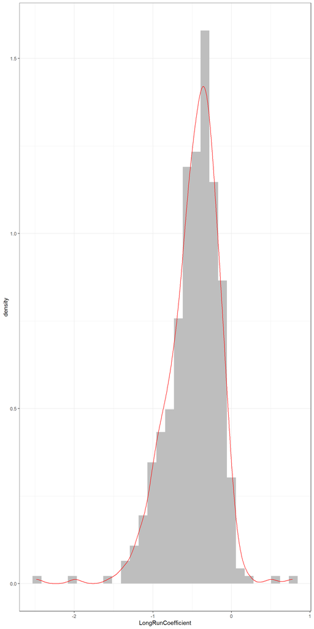

Only few coefficients are in the weird positive spectrum, to be precise 11 out of 411.

## Correlates of LR coefficients

Let’s turn to potential correlates of those long-run coefficients.